# PowerUpR Vignettes

Metin Bulus & Nianbo Dong

November 3, 2016

# Problem

Institue of Education Science (IES) reported that evidence on effectiveness of Saxon Math curriclum on secondary school student’s algebra subject is lacking and further research is needed (U.S. Department of Education, 2016). To evaluate the effectiveness Saxon Math curriculum, assume a 3-level cluster randomized trial is considered where schools are randomly assigned to treatment (Saxon Math curriclum) and a control condition. In the grant proposal number of schools, teachers, and students, and the cost associated with data collection from this sample needs to be justified. We will use [`PowerUpR`](https://github.com/metinbulus/PowerUpR) package (Bulus & Dong, 2016) an implementation of [*PowerUp!*](http://www.causalevaluation.org) (Dong & Maynard, 2013) software in R environment.

# Statistical Model

Due to nesting of students within classrooms and nesting of classrooms within schools, the treatment effect ($\delta$) can be estimated via the following 3-level hierarchical linear model (HLM, Raudenbush & Bryk, 2002)

$$\begin{eqnarray}
L1: Y_{ijk} &=& \beta_{0jk} + \beta_{1jk}X + r_{ijk}, \quad r_{ijk} \thicksim N(0,\sigma_{|X}^2)\\
L2: \beta_{0jk} &=& \gamma_{00k} + \gamma_{01k}W + \mu_{0jk}, \quad \mu_{0jk} \thicksim N(0,\tau_{2|W}^2) \\
\beta_{1jk} &=& \gamma_{10k} \\
L3: \gamma_{00k} &=& \delta T_k + \xi_{002}V + \varsigma_{00k}, \quad \varsigma_{00k} \thicksim N(0,\tau_{3|V}^2) \\
\gamma_{01k} &=& \xi_{010} \\
\gamma_{10k} &=& \xi_{100}
\end{eqnarray}$$

where, $Y$: Student algebra posttest score. $X$: Student algebra pretest score. $W$: Classroom mean algebra pretest score. $V$: School mean algebra pretest score. $T$: Treatment status. Consider the following hypothetical values for design parameters

- Proportion of variance in algebra posttest at the school level ($\tau_3^2$): $.15$
- Proportion of variance in algebra posttest at the classroom level ($\tau_2^2$): $.05$
- Proportion of variance in algebra posttest at the student level ($\sigma^2$): $.65$
- Proportion of variance in algebra posttest explained by school mean algebra pretest: ($R_3^2 = 1 - \frac{\tau_{3|V}^2}{\tau_{3}^2}$): $.45$
- Proportion of variance in algebra posttest explained by classroom mean algebra pretest: ($R_2^2 = 1 - \frac{\tau_{2|W}^2}{\tau_{2}^2}$): $.50$
- Proportion of variance in algebra posttest explained by student algebra pretest: ($R_1^2 = 1 - \frac{\sigma_{|X}^2}{\sigma^2}$): $.55$

Then, intraclass correlation coefficients are

- $\rho_2 = \tau_2^2 / (\sigma^2 + \tau_2^2 + \tau_3^2) = .05 /(.65 + .15 + .05) = 0.059$
- $\rho_3 = \tau_3^2 / (\sigma^2 + \tau_2^2 + \tau_3^2) = .15 /(.65 + .15 + .05) = 0.176$

Let average number of students per classroom be denoted as $n$, average number of classrooms per school as $J$, number of schools as $K$, and proportion of schools allocated to treatment condition as ($P$), then sampling variance of the treatment effects is (Dong & Maynard, 2013, p. 52)

$$var(\delta)=\frac{\rho_3(1-R_3^2)}{P(1-P)K} + \frac{\rho_2(1-R_2^2)}{P(1-P)JK} + \frac{(1-\rho_2-\rho_3)}{P(1-P)nJK}$$

Knowing the sampling variance of the treatment effect, we can find minimum detectable effect size (MDES), statistical power, minimum required sample size (MRSS) for any level, and constrained optimal sample allocation (COSA) solutions as in the following scenarios

# Scenario 1: Find MDES

Further assumptions

- Alpha level ($\alpha$): $0.05$
- Number of schools ($K$): $83$
- Average number of classrooms per school ($J$): $2$
- Average number of students per classroom ($n$) : $10$
- Statistical power ($1-\beta$): $.80$

Given design parameters and further assumptions, what is minimum detectable effect size?

```r
library(PowerUpR)
```

```r
design1 <- mdes.cra3r3(power=.80, rho2=.06, rho3=.18,
                       g3=1, R12=.55, R22=.50, R32=.45,
                       P=.40, n=10, J=2, K=83)
print(design1$mdes)
```

```
##      mdes 95% LCL 95% UCL
## [1,] 0.23   0.069   0.392
```

# Scenario 2: Find Statistical Power

Given design parameters and further assumptions, what is statistical power?

```r
design2 <- power.cra3r3(mdes=.23, rho2=.06, rho3=.18,
                        g3=1, R12=.55, R22=.50, R32=.45,
                        P=.40, n=10, J=2, K=83)
print(design2$power)
```

```
## [1] 0.8
```

# Scenario 3: Find MRSS for Schools (K)

Further assumptions

- Alpha level ($\alpha$): $0.05$
- Average number of classrooms per school ($J$): $2$
- Average number of students per classroom ($n$) : $10$
- Statistical power ($1-\beta$): $.80$
- Minimum detectable effect size (MDES): $.232$

Given design parameters and further assumptions, how many schools should be recruited?

```r
design3 <- mrss.cra3r3(power=.80, mdes=.23, rho2=.06, rho3=.18,
                       g3=1, R12=.55, R22=.50, R32=.45,
                       P=.40, n=10, J=2)
print(design3$round.mrss)
```

```
##       n J  K mdes power
## [1,] 10 2 83 0.23   0.8
```

# Scenario 4: Find MRSS for Classrooms (J)

Given design parameters and further assumptions, how many classrooms should be recruited per school on average?

```r
design4 <- mrss.cra3r3(power=.80, mdes=.23, rho2=.06, rho3=.18,
                       g3=1, R12=.55, R22=.50, R32=.45,
                       P=.40, n=10, K=83)
print(design4$round.mrss)
```

```
##       n J  K mdes power
## [1,] 10 2 83 0.23   0.8
```

# Scenario 5: Find MRSS for Students (n)

Given design parameters and further assumptions, how many studetns should be recruited per classroom on average?

```r
design5 <- mrss.cra3r3(power=.80, mdes=.23, rho2=.06, rho3=.18,
                       g3=1, R12=.55, R22=.50, R32=.45,
                       P=.40, J=2, K=83)
print(design5$round.mrss)
```

```
##       n J  K mdes power
## [1,] 10 2 83 0.23   0.8
```

# Scenario 6: Find Optimal Sample (Constrain Power)

Further assumptions

- Alpha level ($\alpha$): $0.05$
- Statistical power ($1-\beta$): $.80$
- Minimum detectable effect size (MDES): $.232$
- Marginal cost per student ($cn$): $10$
- Marginal cost per classroom ($cJ$): $200$
- Marginal cost per school ($cK$): $500$

Given design parameters and further assumptions, how many schools, classrooms and students should be recruited to achieve 80% power while minimizing the total cost?

```r
design6 <- optimal.cra3r3(cn=10, cJ=200, cK=500, constrain="power", power=.80,
                          mdes=.23, rho2=.06, rho3=.18,
                          g3=1, R12=.55, R22=.50, R32=.45,
                          P=.40)
print(design6$round.optim)
```

```
##       n J  K  cost  mdes power
## [1,] 13 1 97 80510 0.231 0.796
```

```r
print(design6$integer.optim)
```

```
##        n J  K  cost  mdes power
##  [1,] 13 1 98 81340 0.230 0.800
##  [2,] 16 1 95 81700 0.230 0.800
##  [3,] 14 1 97 81480 0.230 0.801
##  [4,] 15 1 96 81600 0.230 0.801
##  [5,] 12 1 99 81180 0.230 0.799
##  [6,] 14 1 96 80640 0.231 0.797
##  [7,] 15 1 95 80750 0.231 0.797
##  [8,] 17 1 95 82650 0.229 0.804
##  [9,] 13 1 99 82170 0.229 0.804
## [10,] 13 1 97 80510 0.231 0.796
```

Note that MDES values in the output are calculated at the specified power value (.80), and power values in the output are calculated at the specified MDES value (.23).

# Scenario 7: Find Optimal Sample (Constrain Power and Number of Classrooms)

Further assumptions

- Alpha level ($\alpha$): $0.05$
- Statistical power ($1-\beta$): $.80$
- Minimum detectable effect size (MDES): $.232$
- Average number of classrooms per school ($J$): $2$
- Marginal cost per student ($cn$): $10$
- Marginal cost per classroom ($cJ$): $200$
- Marginal cost per school ($cK$): $500$

Given design parameters and further assumptions, how many schools, and students should be recrutied to achieve 80% power while minimizing the total cost?

```r
design7 <- optimal.cra3r3(cn=10, cJ=200, cK=500, constrain="power", power=.80, J=2,
                          mdes=.23, rho2=.06, rho3=.18,
                          g3=1, R12=.55, R22=.50, R32=.45,
                          P=.40)
print(design7$round.optim)
```

```
##      n J  K  cost  mdes power
## [1,] 8 2 85 90100 0.231 0.797
```

```r
print(design7$integer.optim)
```

```
##        n J  K   cost  mdes power
##  [1,]  4 3 87 106140 0.230 0.800
##  [2,] 10 2 83  91300 0.230 0.800
##  [3,]  2 6 84 152880 0.230 0.800
##  [4,]  9 2 84  90720 0.230 0.799
##  [5,]  8 2 86  91160 0.230 0.802
##  [6,]  3 4 85 120700 0.231 0.798
##  [7,]  5 3 83 103750 0.231 0.798
##  [8,]  5 3 84 105000 0.229 0.803
##  [9,]  3 4 86 122120 0.229 0.803
## [10,]  7 2 87  90480 0.231 0.797
```

Note that MDES values in the output are calculated at the specified power value (.80), and power values in the output are calculated at the specified MDES value (.23).

# Scenario 8: Find Optimal Sample (Constrain MDES and Number of Classrooms)

Further assumptions

- Alpha level ($\alpha$): $0.05$
- Statistical power ($1-\beta$): $.80$
- Minimum detectable effect size (MDES): $.20$
- Average number of classrooms per school ($J$): $2$
- Marginal cost per student ($cn$): $10$
- Marginal cost per classroom ($cJ$): $200$
- Marginal cost per school ($cK$): $500$

Given design parameters and further assumptions, how many schools, and students should be recruited to achieve an MDES of .20 while minimizing the total cost?

```r
design8 <- optimal.cra3r3(cn=10, cJ=200, cK=500, constrain="mdes", mdes=.20, J=2,
                          power=.80, rho2=.06, rho3=.18,
                          g3=1, R12=.55, R22=.50, R32=.45,
                          P=.40)
print(design8$round.optim)
```

```
##      n J   K   cost  mdes power
## [1,] 9 2 107 115560 0.204 0.786
```

```r
print(design8$integer.optim)
```

```
##        n J   K   cost mdes power
##  [1,] 13 2 106 122960  0.2 0.800
##  [2,] 11 2 108 120960  0.2 0.800
##  [3,] 12 2 107 121980  0.2 0.801
##  [4,] 10 2 109 119900  0.2 0.799
##  [5,] 14 2 105 123900  0.2 0.799
##  [6,]  6 3 107 136960  0.2 0.801
##  [7,]  4 4 107 156220  0.2 0.802
##  [8,] 15 2 105 126000  0.2 0.802
##  [9,]  3 5 106 174900  0.2 0.798
## [10,]  3 5 107 176550  0.2 0.802
```

Note that MDES values in the output are calculated at the specified power value (.80), and power values in the output are calculated at the specified MDES value (.20).

# Scenario 9: Find Optimal Sample (Constrain Cost and Number of Classrooms)

Further assumptions

- Alpha level ($\alpha$): $0.05$
- Statistical power ($1-\beta$): $.80$
- Minimum detectable effect size (MDES): $.20$
- Average number of classrooms per school ($J$): $2$
- Marginal cost per student ($cn$): $10$
- Marginal cost per classroom ($cJ$): $200$
- Marginal cost per school ($cK$): $500$
- Budget: $100,000$

Given design parameters and further assumptions, how many schools, and students should be recruited while maximizing the power?

```r
design9 <- optimal.cra3r3(cn=10, cJ=200, cK=500, constrain="cost", cost=100000, J=2,
                          power=.80, mdes=.20, rho2=.06, rho3=.18,
                          g3=1, R12=.55, R22=.50, R32=.45,
                          P=.40)
print(design9$round.optim)
```

```
##       n J  K   cost mdes power
## [1,] 47 2 55 101200 0.27 0.548
```

```r
print(design9$integer.optim)
```

```
##        n J  K   cost  mdes power
##  [1,] 46 2 55 100100 0.270 0.547
##  [2,] 44 2 56  99680 0.267 0.554
##  [3,] 43 2 57 100320 0.265 0.562
##  [4,] 49 2 53  99640 0.275 0.532
##  [5,] 48 2 54 100440 0.272 0.540
##  [6,] 47 2 54  99360 0.272 0.540
##  [7,] 50 2 53 100700 0.275 0.533
##  [8,] 45 2 56 100800 0.267 0.555
##  [9,] 42 2 57  99180 0.265 0.561
## [10,] 45 2 55  99000 0.270 0.547
```

Note that MDES values in the output are calculated at the specified power value (.80), and power values in the output are calculated at the specified MDES value (.20).

# Scenario 10: Find Optimal Sample (Constrain Cost, Number of Classrooms, Number of Students)

Further assumptions

- Alpha level ($\alpha$): $0.05$
- Statistical power ($1-\beta$): $.80$
- Minimum detectable effect size (MDES): $.20$
- Average number of students per classroom ($J$): $20$
- Average number of classrooms per school ($J$): $2$
- Marginal cost per student ($cn$): $10$
- Marginal cost per classroom ($cJ$): $200$
- Marginal cost per school ($cK$): $500$
- Budget: $100,000$

Given design parameters and further assumptions, how many schools should be recruited while maximizing the power?

```r
design10 <- optimal.cra3r3(cn=10, cJ=200, cK=500, constrain="cost", cost=100000, n=20, J=2,
                           power=.80, mdes=.20, rho2=.06, rho3=.18,
                           g3=1, R12=.55, R22=.50, R32=.45,
                           P=.40)
print(design10$round.optim)
```

```
##       n J  K   cost  mdes power
## [1,] 20 2 77 100100 0.231 0.679
```

```r
print(design10$integer.optim)
```

```
##        n J  K   cost  mdes power
##  [1,] 20 2 77 100100 0.231 0.679
##  [2,] 19 2 78  99840 0.230 0.683
##  [3,] 21 2 76 100320 0.232 0.674
##  [4,] 18 2 79  99540 0.229 0.687
##  [5,] 22 2 75 100500 0.234 0.670
##  [6,] 21 2 75  99000 0.234 0.668
##  [7,] 19 2 79 101120 0.229 0.689
##  [8,] 20 2 76  98800 0.233 0.673
##  [9,] 20 2 78 101400 0.230 0.684
## [10,] 19 2 77  98560 0.232 0.677
```

Note that MDES values in the output are calculated at the specified power value (.80), and power values in the output are calculated at the specified MDES value (.20).

# Plotting X-Y Relationships

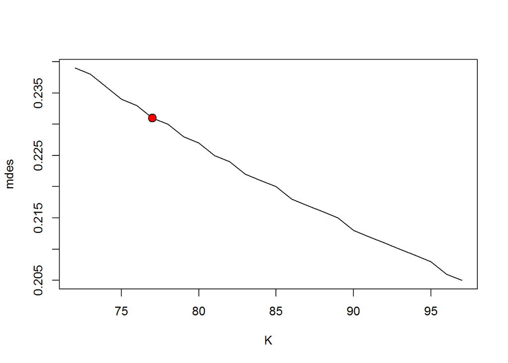

```r
# MDES - MRSS(K)
# Red point indicates the design location
plot(design10, pars=c("mdes","K"))
```

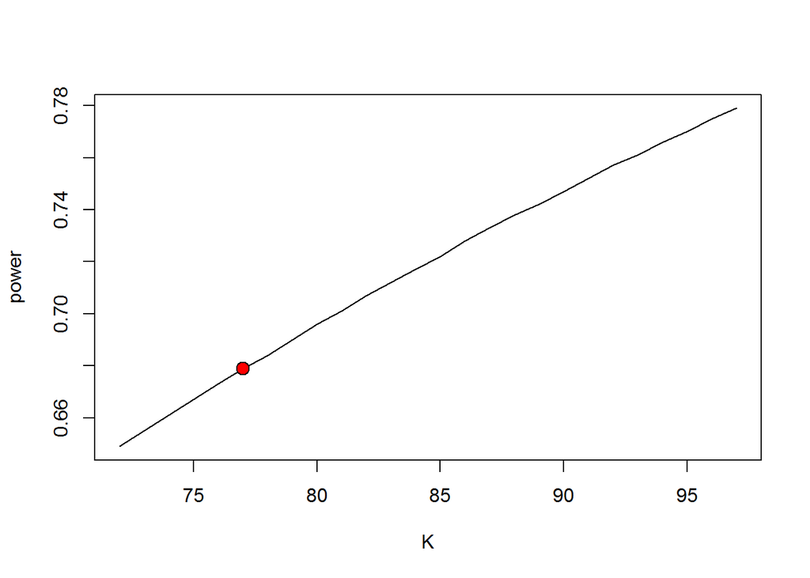

```r
# Power - MRSS(K)
# Red point indicates the design location
plot(design10, pars=c("power","K"))
```

# Plotting X-Y-Z Relationships

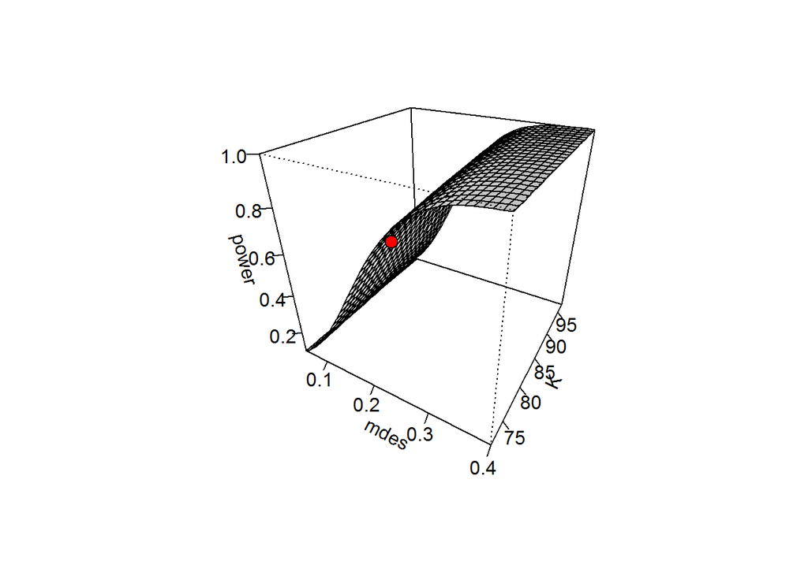

```r
# Perspective plot
# Red point indicates the design location
plot(design10, type="p")
```

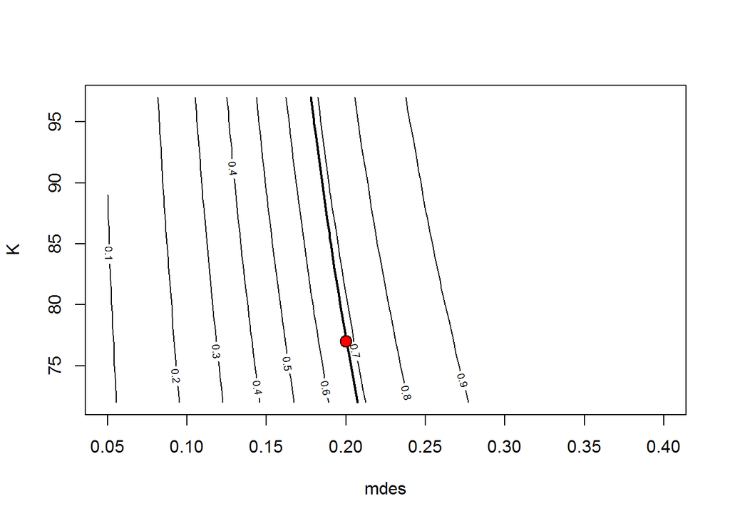

```r
# Contour plot
# Red point indicates the design location
plot(design10, type="c")
```

# Plotting Type I and Type II Error Rates

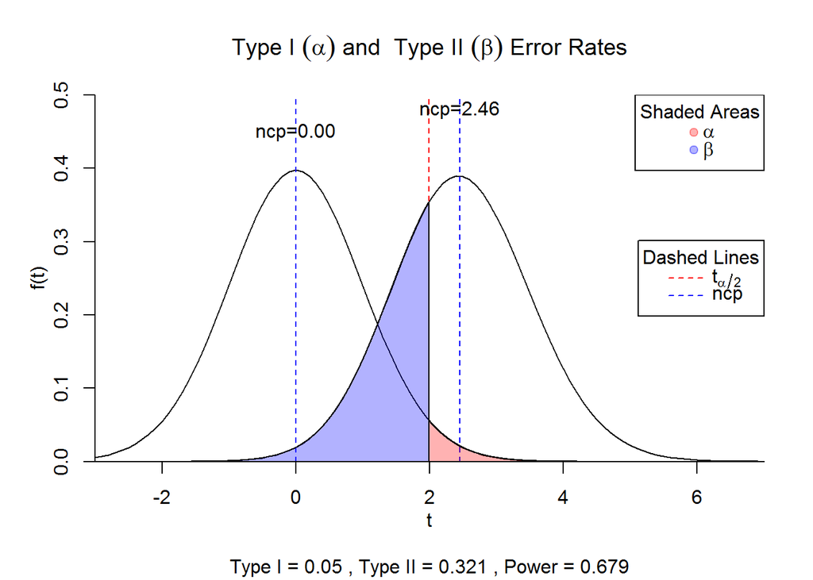

```r
# Type I and Type II Error Rates
# Note: For didactic purpose
t1t2.error(design10)
```

# References

Bulus, M., & Dong, N. (2016). `PowerUpR`: Power Analysis Tools for Individual/Cluster Randomized Trials. R package version 0.1.2.

Dong, N., & Maynard, R. A. (2013). PowerUp!: A Tool for Calculating Minimum Detectable Effect Sizes and Minimum Required Sample Sizes for Experimental and Quasi-Experimental Design Studies, *Journal of Research on Educational Effectiveness, 6(1)*, 24-6.

Raudenbush, S. W., Bryk, A. S. (2002). *Hierarchical linear modeling. Applications and Data Analysis Methods* (2nd ed.) Thousands Oaks: Sage.

U.S. Department of Education, Institute of Education Sciences, What Works Clearinghouse. (2016, May). Secondary Mathematics intervention report: Saxon Math. Retrieved from https://ies.ed.gov/ncee/wwc/Docs/InterventionReports/wwc_saxon_052416.pdf